# Tugas Proses MA(2), AR(2), dan ARMA(2,2)

```r
library(ggplot2)
library(tsibble)
library(tseries)
library(TSA)
library(ggpubr)
set.seed(1234)
n <- 300
```

## Proses MA(2)

Model MA(2) yang akan dibangkitkan mengikuti persamaan:

$$Y_t = e_t + \theta_1 e_{t-1} + \theta_2 e_{t-2}$$

dengan $\theta_1 = 0.4$, $\theta_2 = 0.6$, dan $e_t \sim N(0,1)$ sebanyak 300 data.

### Pembangkitan Data

#### Cara Manual

```r
theta1 <- 0.4
theta2 <- 0.6

set.seed(1234)
e <- rnorm(n + 2)
ma2_manual <- numeric(n)

for (t in 3:(n + 2)) {
  ma2_manual[t - 2] <- e[t] + theta1 * e[t - 1] + theta2 * e[t - 2]
}

ma2_manual <- ts(ma2_manual)
```

#### Dengan `arima.sim`

```r
set.seed(1234)
ma2_sim <- arima.sim(n = n, model = list(ma = c(theta1, theta2))) |> ts()
```

### Plot *Time Series*

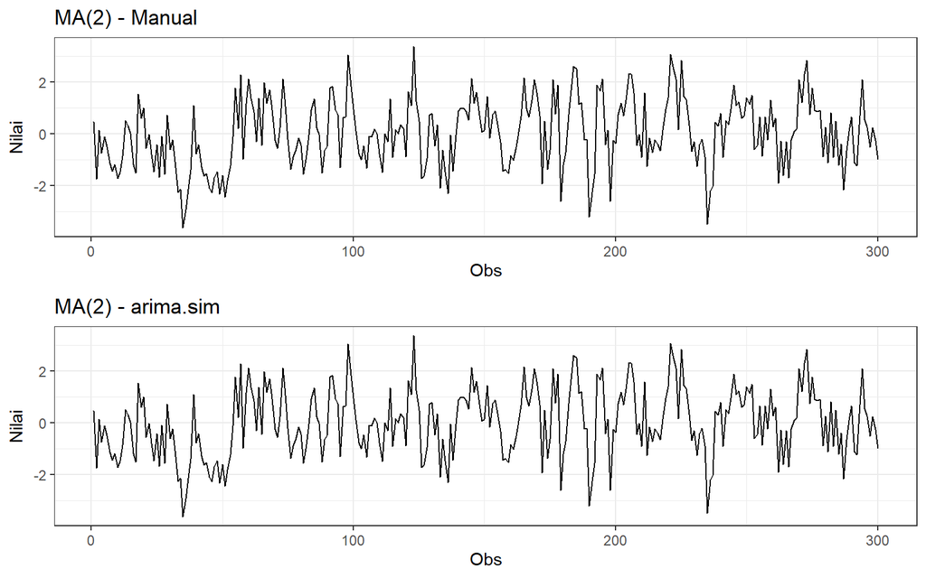

```r
plot_ma2_manual <- ma2_manual |> as_tsibble() |>
  ggplot(aes(x = index, y = value)) + geom_line() + theme_bw() +
  xlab("Obs") + ylab("Nilai") + ggtitle("MA(2) - Manual")

plot_ma2_sim <- ma2_sim |> as_tsibble() |>
  ggplot(aes(x = index, y = value)) + geom_line() + theme_bw() +
  xlab("Obs") + ylab("Nilai") + ggtitle("MA(2) - arima.sim")

ggarrange(plot_ma2_manual, plot_ma2_sim, nrow = 2)
```

Kedua plot *time series* menunjukkan data yang menyebar di sekitar nilai tengah nol dengan lebar pita yang relatif konstan sepanjang waktu, sehingga secara visual data bangkitan terindikasi **stasioner dalam rataan dan ragam**.

### Plot ACF

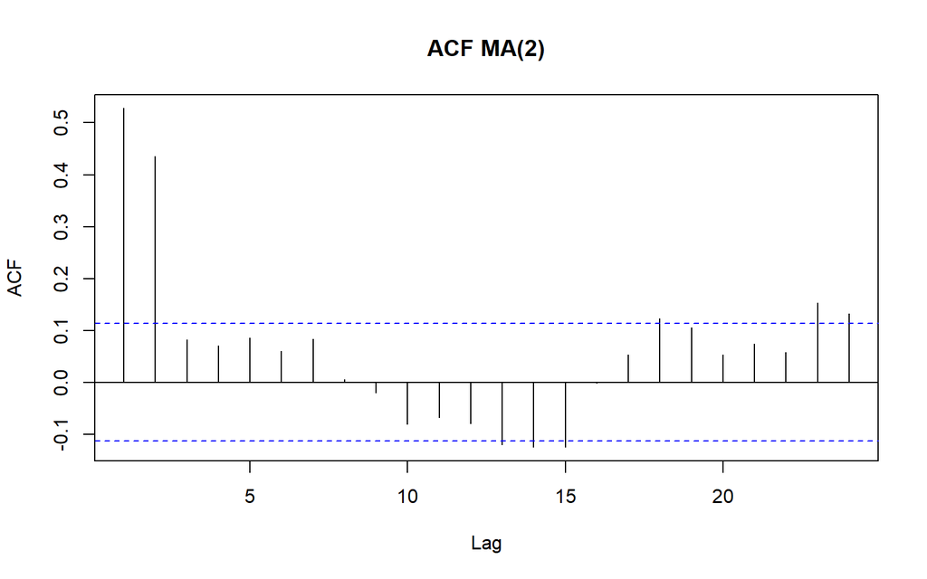

```r
acf(ma2_sim, main = "ACF MA(2)")
```

Plot ACF menunjukkan pola *cuts off* setelah lag ke-2, sesuai dengan sifat teoretis proses MA(2) yang hanya memiliki autokorelasi tidak nol sampai lag ke-2.

### Plot PACF

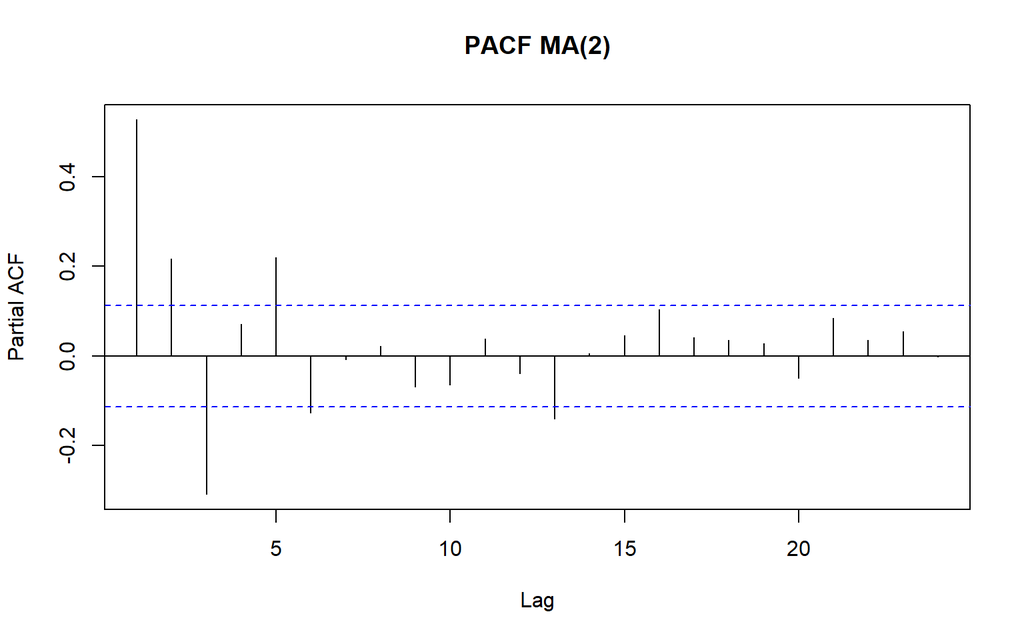

```r
pacf(ma2_sim, main = "PACF MA(2)")
```

Plot PACF menunjukkan pola *tails off* (menurun secara bertahap dan membentuk gelombang), sesuai dengan karakteristik teoretis proses MA.

### Plot EACF

```r
eacf(ma2_sim)
```

```
## AR/MA
##   0 1 2 3 4 5 6 7 8 9 10 11 12 13
## 0 x x o o o o o o o o o  o  x  x
## 1 x x x o o o o o o o o  o  o  o
## 2 x x x x o o o o o o o  o  o  o
## 3 x x x x o o o o o o o  o  o  o
## 4 x x x x o o o o o o o  o  o  o
## 5 x x o x x o x o o o o  o  o  o
## 6 o x o o x o o x o o o  o  o  o
## 7 x o x o x o o x o o o  o  o  o
```

Pada plot EACF, segitiga nol mulai terbentuk pada kolom AR = 0 dan baris MA = 2, yang mengindikasikan proses MA(2).

### Identifikasi Kestasioneran

Proses MA berorde hingga selalu stasioner untuk sembarang nilai parameter $\theta$, karena $Y_t$ merupakan kombinasi linear terhingga dari *white noise* yang stasioner. Hal ini didukung oleh plot *time series* yang stabil di sekitar rataan nol dan plot ACF yang *cuts off* pada lag ke-2. Dengan demikian, data MA(2) yang dibangkitkan **stasioner dalam rataan dan ragam**.

### Scatterplot

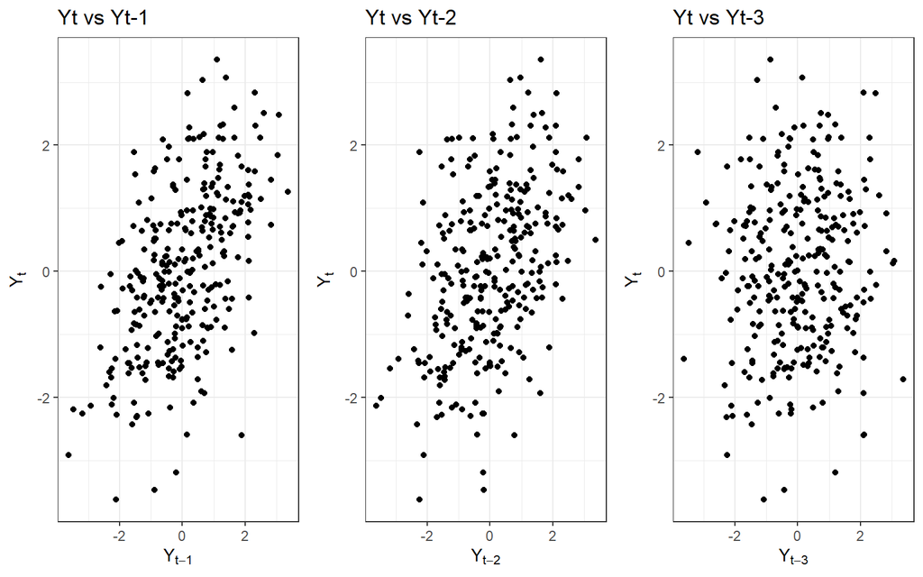

```r
df_ma2 <- data.frame(
  Yt   = ma2_sim[4:n],
  Yt_1 = ma2_sim[3:(n - 1)],
  Yt_2 = ma2_sim[2:(n - 2)],
  Yt_3 = ma2_sim[1:(n - 3)]
)

p1 <- ggplot(df_ma2, aes(x = Yt_1, y = Yt)) + geom_point() + theme_bw() +
  xlab(expression(Y[t-1])) + ylab(expression(Y[t])) + ggtitle("Yt vs Yt-1")

p2 <- ggplot(df_ma2, aes(x = Yt_2, y = Yt)) + geom_point() + theme_bw() +
  xlab(expression(Y[t-2])) + ylab(expression(Y[t])) + ggtitle("Yt vs Yt-2")

p3 <- ggplot(df_ma2, aes(x = Yt_3, y = Yt)) + geom_point() + theme_bw() +
  xlab(expression(Y[t-3])) + ylab(expression(Y[t])) + ggtitle("Yt vs Yt-3")

ggarrange(p1, p2, p3, nrow = 1)
```

Scatterplot $Y_t$ dengan $Y_{t-1}$ dan $Y_t$ dengan $Y_{t-2}$ menunjukkan pola sebaran yang cenderung linear (berkorelasi), sedangkan scatterplot $Y_t$ dengan $Y_{t-3}$ menunjukkan sebaran acak tanpa pola tertentu, sesuai dengan sifat MA(2) yang hanya memiliki autokorelasi pada lag 1 dan 2.

### Perhitungan Autokorelasi

#### Dari Data Bangkitan

```r
acf(ma2_sim, plot = FALSE)$acf[1:4]
```

```
## [1] 0.52794555 0.43532528 0.08203632 0.07076443
```

#### Secara Teoretis

Fungsi autokorelasi proses MA(2) dirumuskan sebagai:

$$\rho_1 = \frac{\theta_1+\theta_1\theta_2}{1+\theta_1^2+\theta_2^2},
\quad
\rho_2 = \frac{\theta_2}{1+\theta_1^2+\theta_2^2}, \quad
\rho_k = 0,\ k \geq 3$$

```r
rho1_ma2 <- (theta1 + theta1 * theta2) / (1 + theta1^2 + theta2^2)
rho2_ma2 <- theta2 / (1 + theta1^2 + theta2^2)

c(rho0 = 1, rho1 = rho1_ma2, rho2 = rho2_ma2, rho3 = 0)
```

```
##      rho0      rho1      rho2      rho3
## 1.0000000 0.4210526 0.3947368 0.0000000
```

Nilai ini juga dapat langsung diperoleh dengan fungsi `ARMAacf()`:

```r
ARMAacf(ma = c(theta1, theta2), lag.max = 5)
```

```
##         0         1         2         3         4         5
## 1.0000000 0.4210526 0.3947368 0.0000000 0.0000000 0.0000000
```

Nilai autokorelasi dari data bangkitan mendekati nilai teoretis, dengan sedikit perbedaan yang wajar karena data bangkitan bersifat acak (galat sampling).

## Proses AR(2)

Model AR(2) yang akan dibangkitkan mengikuti persamaan:

$$Y_t = \phi_1 Y_{t-1} + \phi_2 Y_{t-2} + e_t$$

dengan $\phi_1 = 0.5$, $\phi_2 = 0.2$, dan $e_t \sim N(0,1)$ sebanyak 300 data.

### Pembangkitan Data

#### Cara Manual

```r
phi1 <- 0.5
phi2 <- 0.2
burn <- 50

set.seed(1234)
e_ar <- rnorm(n + burn)
ar2_manual <- numeric(n + burn)

for (t in 3:(n + burn)) {
  ar2_manual[t] <- phi1 * ar2_manual[t - 1] + phi2 * ar2_manual[t - 2] + e_ar[t]
}

# buang burn-in agar efek nilai awal (Y1 = Y2 = 0) hilang
ar2_manual <- ts(ar2_manual[(burn + 1):(n + burn)])
```

#### Dengan `arima.sim`

```r
set.seed(1234)
ar2_sim <- arima.sim(n = n, model = list(ar = c(phi1, phi2))) |> ts()
```

### Plot *Time Series*

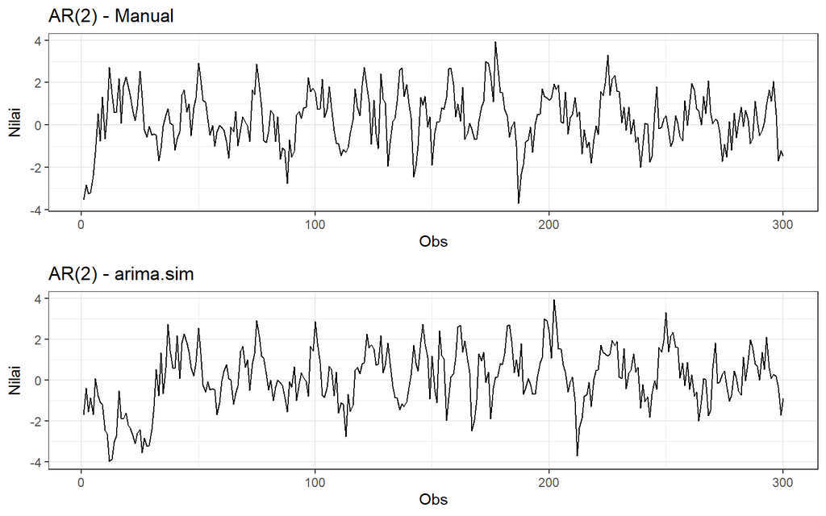

```r
plot_ar2_manual <- ar2_manual |> as_tsibble() |>
  ggplot(aes(x = index, y = value)) + geom_line() + theme_bw() +
  xlab("Obs") + ylab("Nilai") + ggtitle("AR(2) - Manual")

plot_ar2_sim <- ar2_sim |> as_tsibble() |>
  ggplot(aes(x = index, y = value)) + geom_line() + theme_bw() +
  xlab("Obs") + ylab("Nilai") + ggtitle("AR(2) - arima.sim")

ggarrange(plot_ar2_manual, plot_ar2_sim, nrow = 2)
```

Kedua plot *time series* menyebar di sekitar nilai tengah nol dengan lebar pita yang relatif konstan, sehingga secara visual data bangkitan terindikasi **stasioner dalam rataan dan ragam**.

### Plot ACF

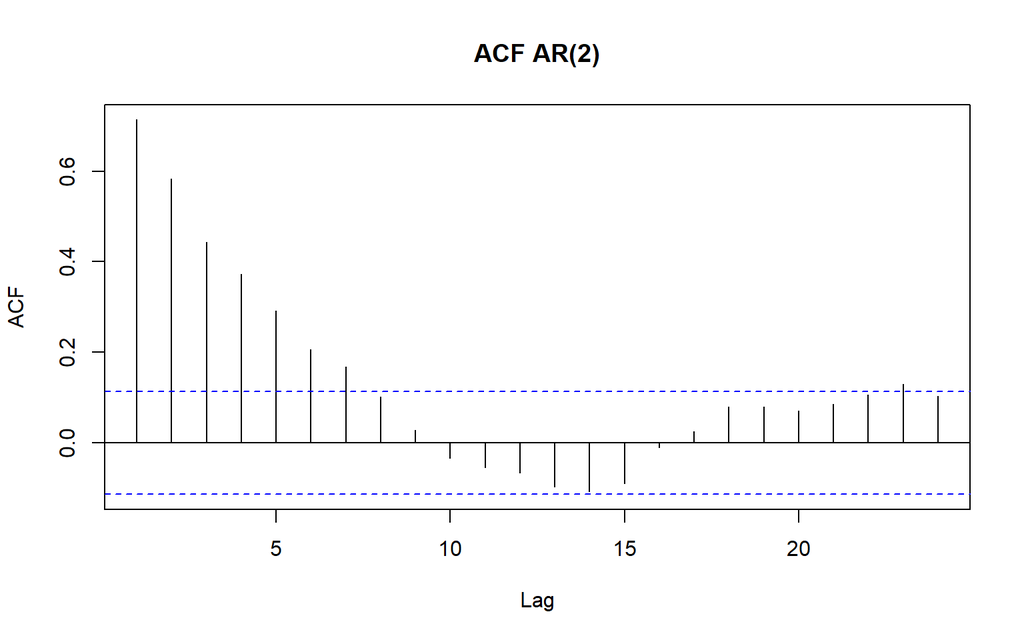

```r
acf(ar2_sim, main = "ACF AR(2)")
```

Plot ACF menunjukkan pola *tails off* (menurun secara eksponensial), sesuai dengan karakteristik teoretis proses AR.

### Plot PACF

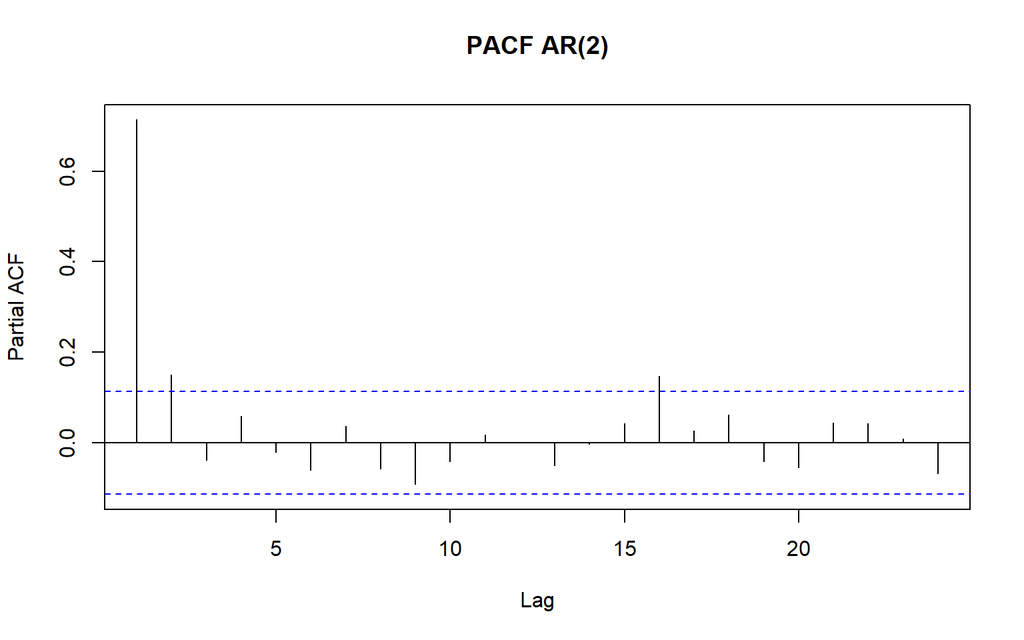

```r
pacf(ar2_sim, main = "PACF AR(2)")
```

Plot PACF menunjukkan pola *cuts off* setelah lag ke-2, sesuai dengan sifat teoretis proses AR(2) yang hanya memiliki autokorelasi parsial tidak nol sampai lag ke-2.

### Plot EACF

```r
eacf(ar2_sim)
```

```
## AR/MA
##   0 1 2 3 4 5 6 7 8 9 10 11 12 13
## 0 x x x x x x x o o o o  o  o  o
## 1 x o o o o o o o o o o  o  o  o
## 2 x o o o o o o o o o o  o  o  o
## 3 x x o o o o o o o o o  o  o  o
## 4 x x o o o o o o o o o  o  o  o
## 5 x x x o o o o o o o o  o  o  o
## 6 x x x o o o o o o o o  o  o  o
## 7 x x x o x x o o o o o  o  o  o
```

### Identifikasi Kestasioneran

Syarat kestasioneran proses AR(2) adalah:

$$\phi_1+\phi_2<1,\quad \phi_2-\phi_1<1,\quad |\phi_2|<1$$

```r
c(
  syarat1 = phi1 + phi2 < 1,
  syarat2 = phi2 - phi1 < 1,
  syarat3 = abs(phi2) < 1
)
```

```
## syarat1 syarat2 syarat3
##    TRUE    TRUE    TRUE
```

Ketiga syarat terpenuhi (bernilai `TRUE`), sehingga secara teoretis proses AR(2) dengan $\phi_1 = 0.5$ dan $\phi_2 = 0.2$ **stasioner**. Hal ini sesuai dengan hasil eksplorasi plot *time series*, ACF, dan PACF di atas.

### Scatterplot

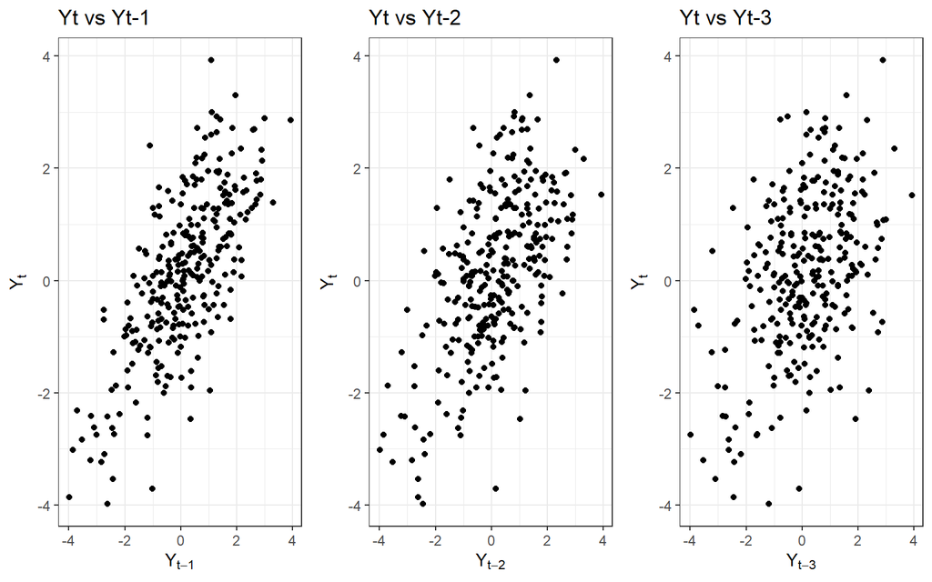

```r
df_ar2 <- data.frame(
  Yt   = ar2_sim[4:n],
  Yt_1 = ar2_sim[3:(n - 1)],
  Yt_2 = ar2_sim[2:(n - 2)],
  Yt_3 = ar2_sim[1:(n - 3)]
)

p1 <- ggplot(df_ar2, aes(x = Yt_1, y = Yt)) + geom_point() + theme_bw() +
  xlab(expression(Y[t-1])) + ylab(expression(Y[t])) + ggtitle("Yt vs Yt-1")

p2 <- ggplot(df_ar2, aes(x = Yt_2, y = Yt)) + geom_point() + theme_bw() +
  xlab(expression(Y[t-2])) + ylab(expression(Y[t])) + ggtitle("Yt vs Yt-2")

p3 <- ggplot(df_ar2, aes(x = Yt_3, y = Yt)) + geom_point() + theme_bw() +
  xlab(expression(Y[t-3])) + ylab(expression(Y[t])) + ggtitle("Yt vs Yt-3")

ggarrange(p1, p2, p3, nrow = 1)
```

Berbeda dengan MA(2), ketiga scatterplot ($Y_t$ vs $Y_{t-1}$, $Y_{t-2}$, maupun $Y_{t-3}$) pada proses AR(2) menunjukkan pola sebaran yang masih cenderung linear meskipun semakin melemah seiring bertambahnya lag, karena pada proses AR autokorelasi tidak terputus (*tails off*) dan secara teoretis tidak pernah benar-benar nol.

### Perhitungan Autokorelasi

#### Dari Data Bangkitan

```r
acf(ar2_sim, plot = FALSE)$acf[1:4]
```

```
## [1] 0.7135307 0.5828365 0.4427355 0.3733660
```

#### Secara Teoretis

Fungsi autokorelasi proses AR(2) diperoleh dari persamaan Yule-Walker:

$$\rho_1 = \frac{\phi_1}{1-\phi_2}, \quad
\rho_2 = \phi_2+\frac{\phi_1^2}{1-\phi_2}, \quad
\rho_k = \phi_1\rho_{k-1}+\phi_2\rho_{k-2},\ k\geq 3$$

```r
rho1_ar2 <- phi1 / (1 - phi2)
rho2_ar2 <- phi2 + (phi1^2) / (1 - phi2)
rho3_ar2 <- phi1 * rho2_ar2 + phi2 * rho1_ar2

c(rho0 = 1, rho1 = rho1_ar2, rho2 = rho2_ar2, rho3 = rho3_ar2)
```

```
##    rho0    rho1    rho2    rho3
## 1.00000 0.62500 0.51250 0.38125
```

Nilai ini juga dapat langsung diperoleh dengan fungsi `ARMAacf()`:

```r
ARMAacf(ar = c(phi1, phi2), lag.max = 5)
```

```
##         0         1         2         3         4         5
## 1.0000000 0.6250000 0.5125000 0.3812500 0.2931250 0.2228125
```

Nilai autokorelasi dari data bangkitan mendekati nilai teoretis, dengan sedikit perbedaan yang wajar karena galat sampling.

## Proses ARMA(2,2)

Model ARMA(2,2) yang akan dibangkitkan mengikuti persamaan:

$$Y_t = \phi_1 Y_{t-1}+\phi_2 Y_{t-2}+e_t+\theta_1 e_{t-1}+\theta_2
e_{t-2}$$

dengan $\phi_1 = 0.5$, $\phi_2 = 0.2$, $\theta_1 = 0.4$, $\theta_2 = 0.6$, dan $e_t \sim N(0,1)$ sebanyak 300 data.

### Pembangkitan Data

#### Cara Manual

```r
set.seed(1234)
e_arma <- rnorm(n + burn)
arma22_manual <- numeric(n + burn)

for (t in 3:(n + burn)) {
  arma22_manual[t] <- phi1 * arma22_manual[t - 1] + phi2 * arma22_manual[t - 2] +
    e_arma[t] + theta1 * e_arma[t - 1] + theta2 * e_arma[t - 2]
}

arma22_manual <- ts(arma22_manual[(burn + 1):(n + burn)])
```

#### Dengan `arima.sim`

```r
set.seed(1234)
arma22_sim <- arima.sim(
  n = n,
  model = list(ar = c(phi1, phi2), ma = c(theta1, theta2))
) |> ts()
```

### Plot *Time Series*

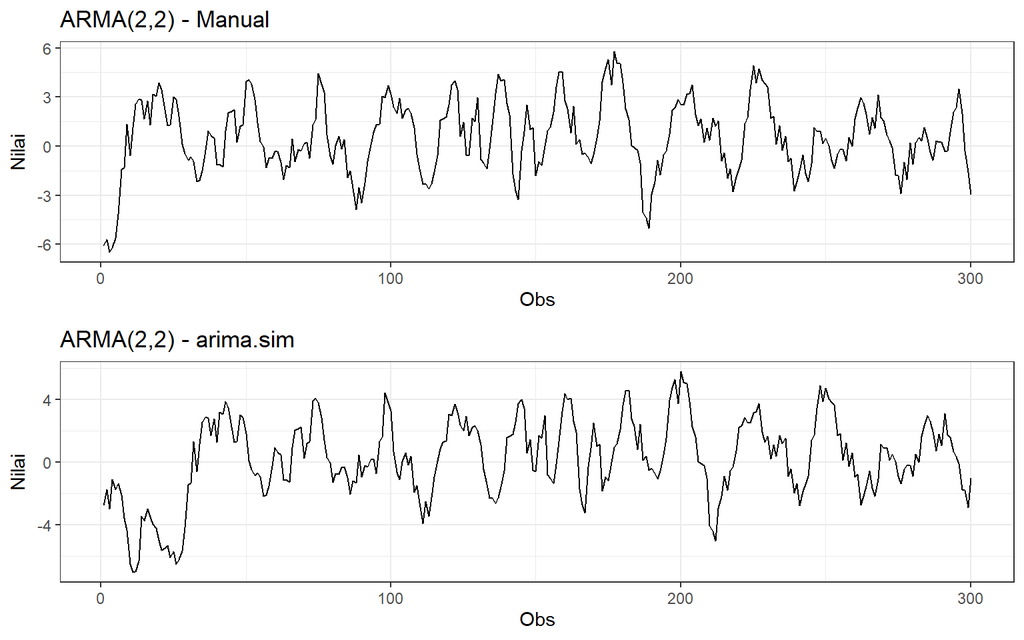

```r
plot_arma_manual <- arma22_manual |> as_tsibble() |>
  ggplot(aes(x = index, y = value)) + geom_line() + theme_bw() +
  xlab("Obs") + ylab("Nilai") + ggtitle("ARMA(2,2) - Manual")

plot_arma_sim <- arma22_sim |> as_tsibble() |>
  ggplot(aes(x = index, y = value)) + geom_line() + theme_bw() +
  xlab("Obs") + ylab("Nilai") + ggtitle("ARMA(2,2) - arima.sim")

ggarrange(plot_arma_manual, plot_arma_sim, nrow = 2)
```

Kedua plot *time series* menyebar di sekitar nilai tengah nol dengan lebar pita yang relatif konstan, sehingga secara visual data bangkitan terindikasi **stasioner dalam rataan dan ragam**.

### Plot ACF

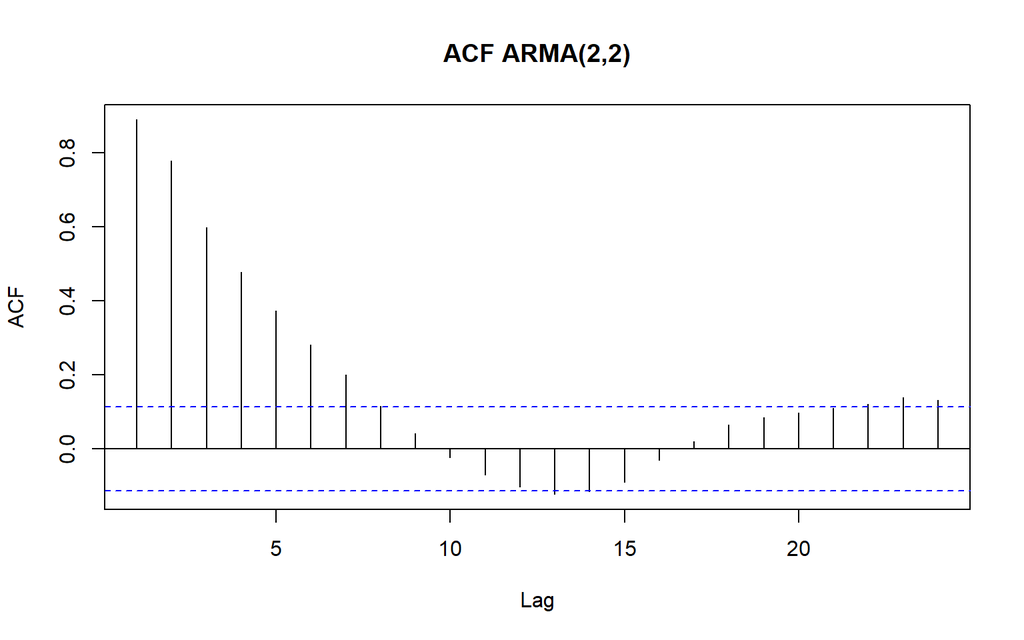

```r
acf(arma22_sim, main = "ACF ARMA(2,2)")
```

Plot ACF menunjukkan pola *tails off*, gabungan dari komponen AR dan MA yang sama-sama memengaruhi bentuk peluruhan autokorelasi.

### Plot PACF

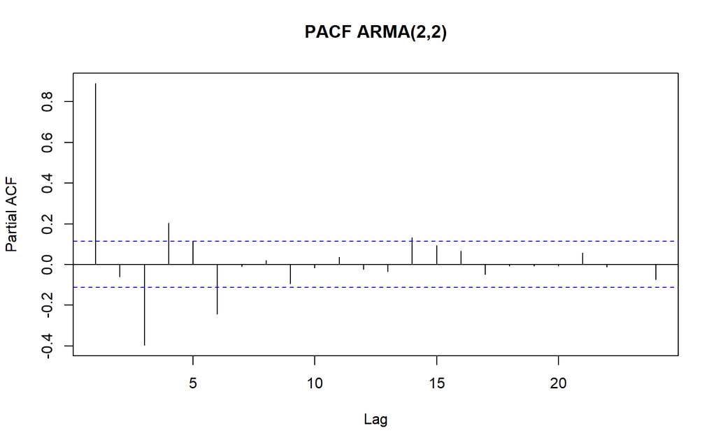

```r
pacf(arma22_sim, main = "PACF ARMA(2,2)")
```

Plot PACF juga menunjukkan pola *tails off*, bukan *cuts off* tegas pada lag tertentu, karena adanya komponen MA yang membuat PACF meluruh secara bertahap.

### Plot EACF

```r
eacf(arma22_sim)
```

```
## AR/MA
##   0 1 2 3 4 5 6 7 8 9 10 11 12 13
## 0 x x x x x x x o o o o  o  x  o
## 1 o x o o o o x o o o o  o  o  o
## 2 x x o o o o o o o o o  o  o  o
## 3 x x x x o o o o o o o  o  o  o
## 4 x x x x o o o o o o o  o  o  o
## 5 x x x x x x x o o o o  o  o  o
## 6 o o x o x x o o o o o  o  o  o
## 7 x o x x x x o x o o o  o  o  o
```

Pada plot EACF, segitiga nol mulai terbentuk pada sekitar kolom AR = 2 dan baris MA = 2, yang mengindikasikan proses ARMA(2,2).

### Identifikasi Kestasioneran

Kestasioneran proses ARMA ditentukan oleh komponen AR-nya saja (komponen MA selalu stasioner untuk order hingga). Dengan syarat yang sama seperti AR(2):

```r
c(
  syarat1 = phi1 + phi2 < 1,
  syarat2 = phi2 - phi1 < 1,
  syarat3 = abs(phi2) < 1
)
```

```
## syarat1 syarat2 syarat3
##    TRUE    TRUE    TRUE
```

Ketiga syarat terpenuhi sehingga proses ARMA(2,2) dengan parameter di atas **stasioner**. Hal ini sesuai dengan hasil eksplorasi plot *time series*, ACF, dan PACF.

### Scatterplot

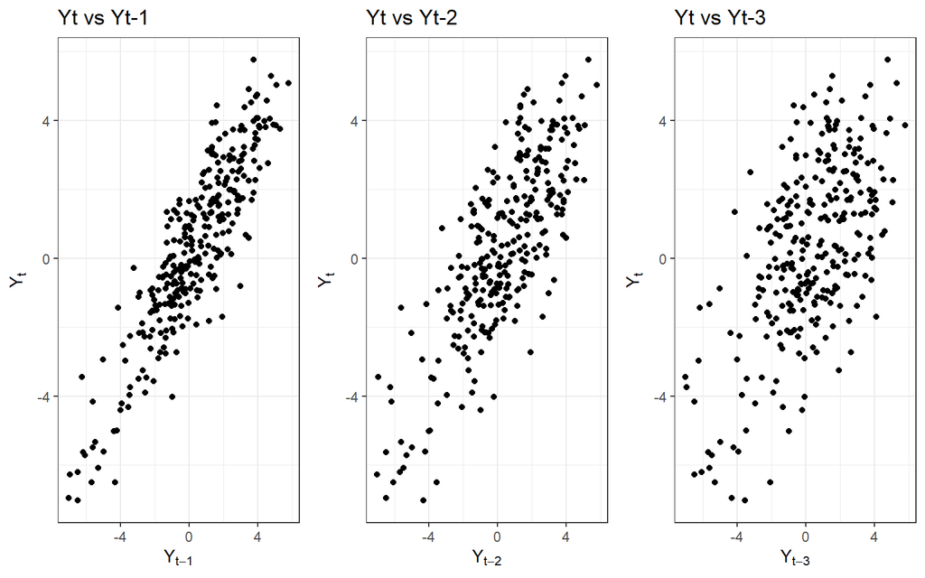

```r
df_arma <- data.frame(
  Yt   = arma22_sim[4:n],
  Yt_1 = arma22_sim[3:(n - 1)],
  Yt_2 = arma22_sim[2:(n - 2)],
  Yt_3 = arma22_sim[1:(n - 3)]
)

p1 <- ggplot(df_arma, aes(x = Yt_1, y = Yt)) + geom_point() + theme_bw() +
  xlab(expression(Y[t-1])) + ylab(expression(Y[t])) + ggtitle("Yt vs Yt-1")

p2 <- ggplot(df_arma, aes(x = Yt_2, y = Yt)) + geom_point() + theme_bw() +
  xlab(expression(Y[t-2])) + ylab(expression(Y[t])) + ggtitle("Yt vs Yt-2")

p3 <- ggplot(df_arma, aes(x = Yt_3, y = Yt)) + geom_point() + theme_bw() +
  xlab(expression(Y[t-3])) + ylab(expression(Y[t])) + ggtitle("Yt vs Yt-3")

ggarrange(p1, p2, p3, nrow = 1)
```

Seperti pada AR(2), scatterplot pada ketiga lag ARMA(2,2) masih menunjukkan pola sebaran yang cenderung linear meskipun semakin melemah pada lag yang lebih jauh, karena adanya komponen AR yang membuat autokorelasi meluruh secara bertahap (*tails off*) dan tidak pernah benar-benar terputus.

### Perhitungan Autokorelasi

#### Dari Data Bangkitan

```r
acf(arma22_sim, plot = FALSE)$acf[1:4]
```

```
## [1] 0.8893625 0.7786694 0.5983096 0.4774182
```

#### Secara Teoretis

Untuk proses ARMA(2,2), autokorelasi pada lag $k>2$ (setelah orde MA) mengikuti rekursi yang sama seperti komponen AR:

$$\rho_k = \phi_1\rho_{k-1}+\phi_2\rho_{k-2}, \quad k>2$$

sedangkan $\rho_0$, $\rho_1$, dan $\rho_2$ melibatkan bobot $\psi$ dari representasi $MA(\infty)$ sehingga tidak memiliki bentuk tertutup yang sederhana. Oleh karena itu, nilai teoretisnya dihitung menggunakan fungsi `ARMAacf()`:

```r
ARMAacf(ar = c(phi1, phi2), ma = c(theta1, theta2), lag.max = 5)
```

```
##         0         1         2         3         4         5
## 1.0000000 0.8591993 0.7491908 0.5464353 0.4230558 0.3208149
```

Nilai autokorelasi dari data bangkitan mendekati nilai teoretis tersebut, dengan sedikit perbedaan yang wajar karena data bangkitan bersifat acak (galat sampling).

## Ringkasan

```r
ringkasan <- data.frame(
  Proses = c("MA(2)", "AR(2)", "ARMA(2,2)"),
  Stasioner = c("Ya", "Ya", "Ya"),
  Pola_ACF = c("Cuts off lag 2", "Tails off", "Tails off"),
  Pola_PACF = c("Tails off", "Cuts off lag 2", "Tails off")
)
ringkasan
```

```
##      Proses Stasioner       Pola_ACF      Pola_PACF
## 1     MA(2)        Ya Cuts off lag 2      Tails off
## 2     AR(2)        Ya      Tails off Cuts off lag 2
## 3 ARMA(2,2)        Ya      Tails off      Tails off
```

Ketiga proses yang dibangkitkan (MA(2), AR(2), dan ARMA(2,2)) bersifat **stasioner dalam rataan dan ragam**, dengan pola ACF dan PACF yang sesuai dengan karakteristik teoretis masing-masing model: MA(2) *cuts off* pada ACF, AR(2) *cuts off* pada PACF, dan ARMA(2,2) *tails off* pada keduanya.